# Introduction

## Overview

Nowadays, people are getting more and more concerned about food quality and scientist are starting to find the correlation between food quality and people's health. From our study, we find that the quality of restaurants are closely related to the indicator or cancer disease. After that, we'd like to know how we can improve the life quality of residents. The main problem we’re trying to solve here is to see if the number of 311 service requests filed by people in each Neighborhood Tabulation Area is related to its local food embellishment score, median income, health condition, and different seasons.

Methodology We aggregate the complaint types filed under Department of Health and Mental Hygiene and NYC Department of Sanitation into four major category: Sanitation - Containing Dirty Conditions and Sanitary Conditions Food Quality - Containing Food Establishment, Food Poisoning, Drinking Water, Calorie Labeling, Trans Fat, Water System, Water Quality, Annual Inspection, Annual/Cycle Inspection Air Quality - Containing Asbestos, Indoor Air Quality, Smoking, Mold Rodent - Containing Rodent

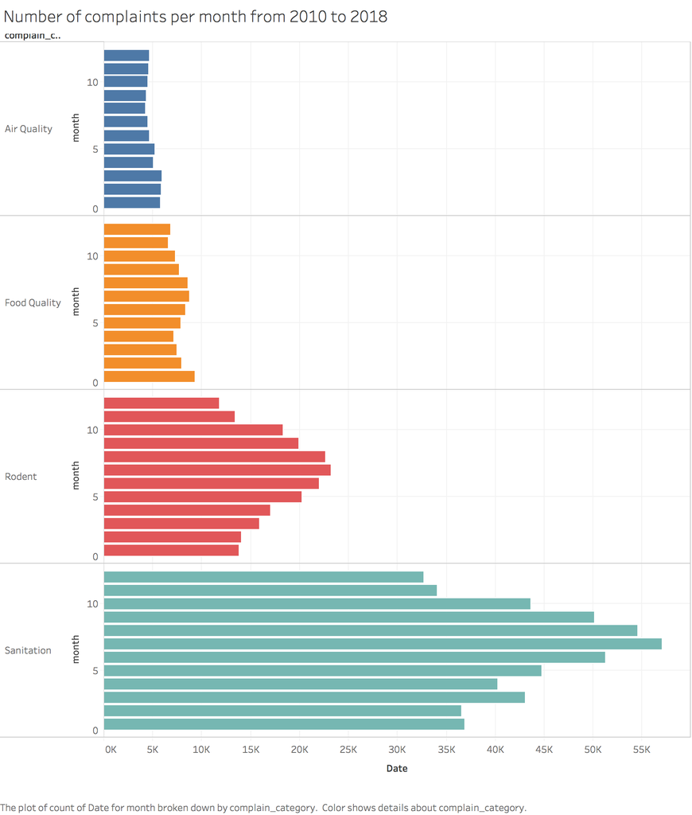

```python
Image(path+'pic/2.png')
```

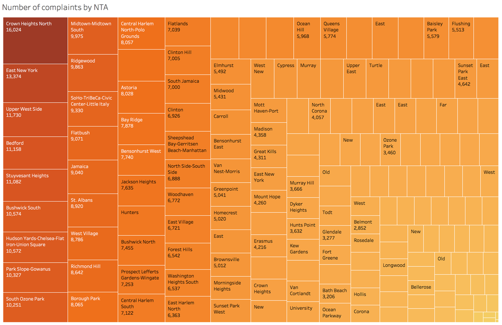

```python
Image(path+'pic/3.png')
```

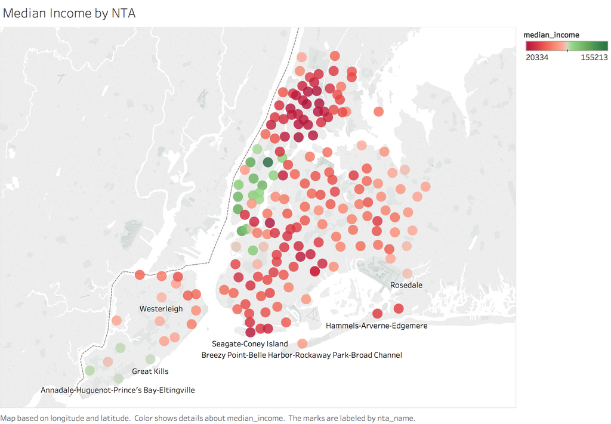

```python
Image(path+'pic/1.png')
```

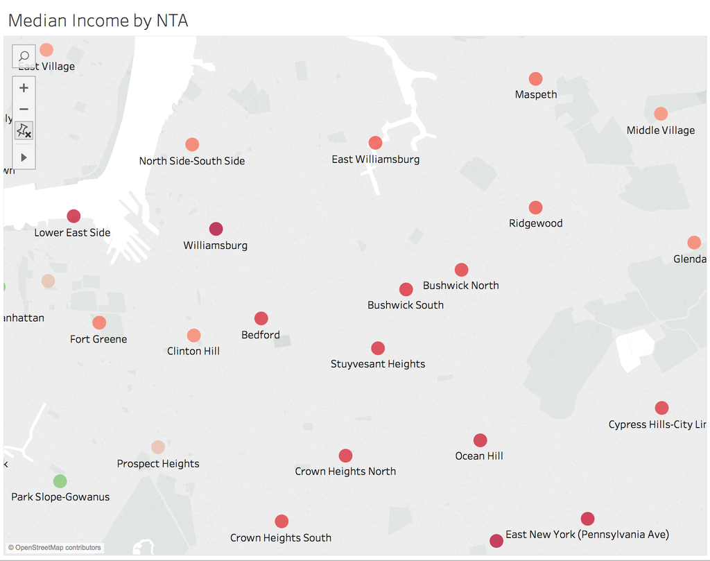

```python
Image(path+'4.png')
```

## Key Insight

Accordingly, we propose these strategies for government to improve the health and well-being of the people:

1. In the summer time, the government should pay more attention to the sanitation of restaurant as well as the whole street to decrease the possibility of people getting ill.

## Main Difficulty

1. Map the restaurant data to the NTA Level using the polygon shape that define the boundaries of the given NTA code.
2. Generate numerical features from string-shaped and categorical data
3. Group the 311 complaints and generate endogenous data

# Data Process

```python
import warnings
warnings.filterwarnings('ignore')

import os

import pandas as pd
import geopandas as gpd
from geopandas import sjoin
```

```python
dataopen_raw = '~/Google Drive/PrincetonDataOpen/'
dataopen_processed = os.path.join(dataopen_raw, 'processed')
```

# Health and food

We want to explore whether food quality will have big influences to community health. We use food_service_establishment, community_health and demographics_state table to do our analysis. These data are all county-level. We firstly explore the correlation between diseases and food inspections on different counties.

```python
health = pd.read_csv('D:/Documents/Datathon Materials/community_health.csv')
health.head()
```

|  | county_name | health_topic | indicator | event_count | avg_num_of_denominator | unit_measurement | precent_or_rate | low_limit_95p_CI | upp_limit_95p_CI | data_comment | year | data_source | lat_long |
| --- | --- | --- | --- | --- | --- | --- | --- | --- | --- | --- | --- | --- | --- |
| 0 | Albany | Family Planning/Natality Indicators | Percentage of births within 24 months of previ... | 2043.0 | 3144.0 | Percentage | 21.7 | NaN | NaN | NaN | 2012-2014 | 2012-2014 Vital Statistics Data as of May, 2016 | (42.678066, -73.814233) |
| 1 | Allegany | Family Planning/Natality Indicators | Percentage of births within 24 months of previ... | 399.0 | 487.0 | Percentage | 27.3 | NaN | NaN | NaN | 2012-2014 | 2012-2014 Vital Statistics Data as of May, 2016 | (42.226801, -78.020567) |
| 2 | Bronx | Family Planning/Natality Indicators | Percentage of births within 24 months of previ... | 10032.0 | 21249.0 | Percentage | 15.7 | NaN | NaN | NaN | 2012-2014 | 2012-2014 Vital Statistics Data as of May, 2016 | (40.85589, -73.868294) |
| 3 | Broome | Family Planning/Natality Indicators | Percentage of births within 24 months of previ... | 1654.0 | 2083.0 | Percentage | 26.5 | NaN | NaN | NaN | 2012-2014 | 2012-2014 Vital Statistics Data as of May, 2016 | (42.122015, -75.933191) |
| 4 | Capital Region | Family Planning/Natality Indicators | Percentage of births within 24 months of previ... | 6273.0 | 9774.0 | Percentage | 21.4 | NaN | NaN | NaN | 2012-2014 | 2012-2014 Vital Statistics Data as of May, 2016 | NaN |

```python
food_state = pd.read_csv('D:/Documents/Datathon Materials/food_establishment_inspections.csv')
food_state['year'] = pd.to_datetime(food_state.inspection_date).dt.year
food_state.head()
```

|  | inspection_date | violation_item | critical_violation | num_critical | num_critical_not_corrected | num_noncritical | county | zipcode | municipality | permit_expiration_date | nys_inspection_id | latitude | longitude | year |
| --- | --- | --- | --- | --- | --- | --- | --- | --- | --- | --- | --- | --- | --- | --- |
| 0 | 10/3/2017 | 15A | Not Critical Violation | 0.0 | 0.0 | 3.0 | NIAGARA | 14094 | LOCKPORT | 10/31/2018 | 286815 | 43.124090 | -78.736710 | 2017 |
| 1 | 9/9/2015 | 10B | Not Critical Violation | 0.0 | 0.0 | 1.0 | PUTNAM | 10512 | CARMEL | 3/31/2018 | 299840 | 41.429351 | -73.679427 | 2015 |
| 2 | 4/15/2010 | None | Not Critical Violation | 0.0 | 0.0 | 0.0 | ROCKLAND | 10927 | HAVERSTRAW | 4/30/2018 | 303561 | 41.198585 | -73.981861 | 2010 |
| 3 | 7/12/2012 | None | Not Critical Violation | 0.0 | 0.0 | 0.0 | SENECA | 14541 | VARICK | 7/30/2018 | 308241 | 42.786649 | -76.809727 | 2012 |
| 4 | 8/26/2011 | None | Not Critical Violation | 0.0 | 0.0 | 0.0 | TOMPKINS | 14850 | ITHACA | 3/31/2018 | 313774 | 42.442929 | -76.513121 | 2011 |

```python
avail_state = set(health.county_name.str.upper().unique()).intersection(set(food_state.county.unique()))
food_state = food_state.loc[food_state.county.isin(avail_state)]
health['county'] = health['county_name'].str.upper()
health = health.loc[health.county.isin(avail_state)]
```

```python
reg_dataset = pd.DataFrame(index=avail_state)
reg_dataset.head()
```

| GREENE |
| --- |
| MADISON |
| ONTARIO |
| MONROE |
| ROCKLAND |

[figure not shown]

```python
food_state.head()
ins_critical = {}
ins_not_corrected = {}
ins_noncritical = {}
for item in reg_dataset.index:
    ins_critical[item] = food_state.loc[food_state.county==item].num_critical.sum()
    ins_not_corrected[item] = food_state.loc[food_state.county==item].num_critical_not_corrected.sum()
    ins_noncritical[item] = food_state.loc[food_state.county==item].num_noncritical.sum()
```

```python
reg_dataset['critical'] = reg_dataset.index.to_series().map(ins_critical)
reg_dataset['not_corrected'] = reg_dataset.index.to_series().map(ins_not_corrected)
reg_dataset['noncritical'] = reg_dataset.index.to_series().map(ins_noncritical)
reg_dataset.head()
```

|  | critical | not_corrected | noncritical |
| --- | --- | --- | --- |
| GREENE | 7306.0 | 142.0 | 60270.0 |
| MADISON | 3872.0 | 66.0 | 29693.0 |
| ONTARIO | 9965.0 | 188.0 | 46406.0 |
| MONROE | 51691.0 | 476.0 | 395460.0 |
| ROCKLAND | 13457.0 | 63.0 | 83731.0 |